# summit_exploration

2026-03-03

## Quick look at 1990 and 1991 hoop trap data with geog info for Summit Lake

```r
length_dist<- read_excel("lengths_combined.xlsx")

# abundance estimates are already very bad.

#read in data from 1889 abd 1991

length_dist
```

```
## # A tibble: 471 × 6
##    `1986` `1987` `1988` `1989` `1991` `1990`
##     <dbl>  <dbl>  <dbl>  <dbl>  <dbl>  <dbl>
##  1    342    396    610    507    302    300
##  2    395    434    382    422    305    319
##  3    472    402    305    516    328    347
##  4    436    412    542    550    332    350
##  5    502    490    372    384    337    364
##  6    360    373    545    370    340    368
##  7    480    440    390    570    360    374
##  8    370    384    565    774    364    375
##  9    400    327    425    697    370    381
## 10    405    350    512    567    381    384
## # ℹ 461 more rows
```

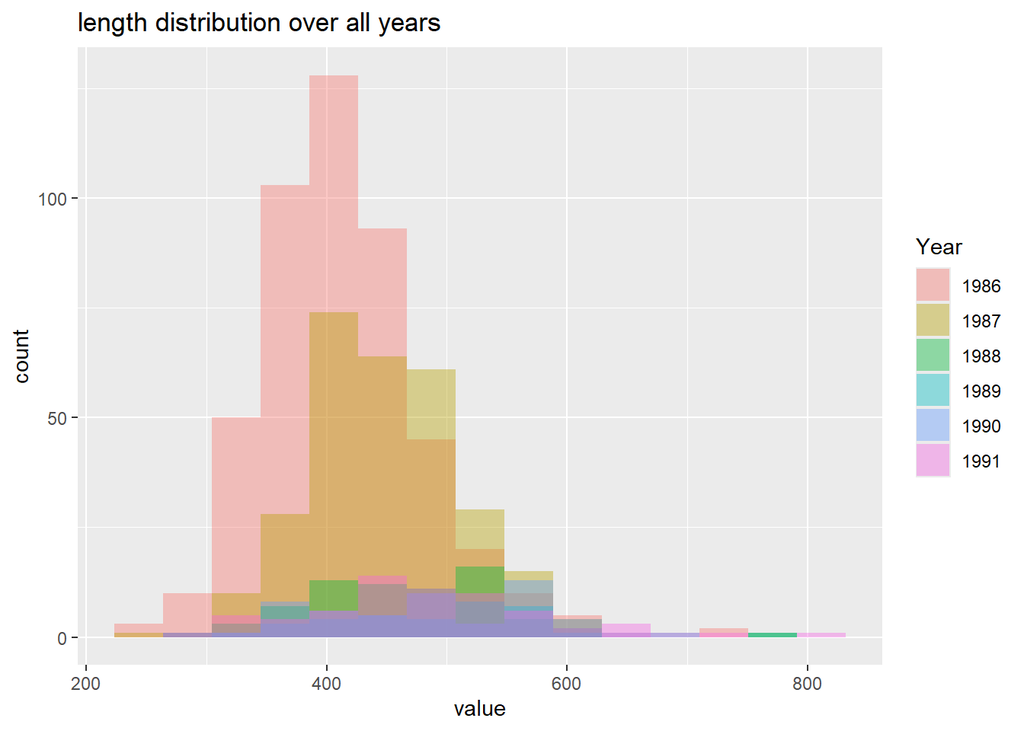

```r
df_long <- length_dist %>%
  pivot_longer(
    cols = everything(),
    names_to = "year",
    values_to = "value"
  )


ggplot(df_long, aes(x = value, fill = factor(year))) +
  geom_histogram(position = "identity", alpha = 0.4, bins = 15) +
  labs(fill = "Year", title = "length distribution over all years")
```

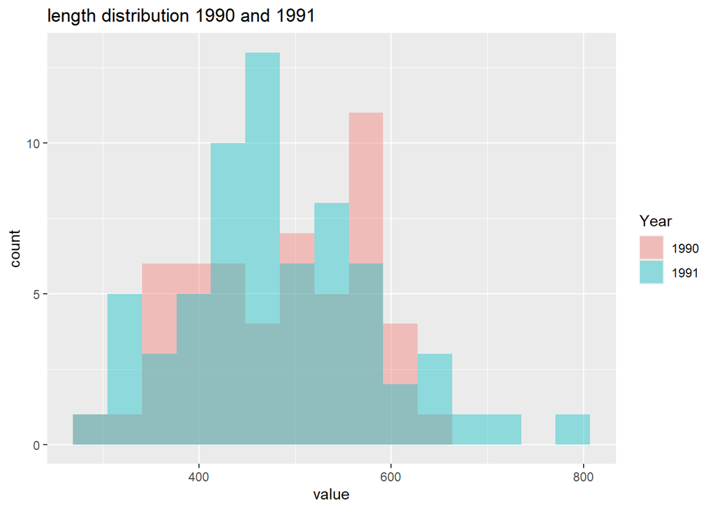

```r
df_long_recent<-df_long%>%
  filter(year %in% c("1990", "1991"))


ggplot(df_long_recent, aes(x = value, fill = factor(year))) +
  geom_histogram(position = "identity", alpha = 0.4, bins = 15) +
  labs(fill = "Year", title = "length distribution 1990 and 1991")
```

### these length distributions look similar enough. Probably consistent distribution across time although no formal testing was done. However, the sample size is relatively small, particularly for 1990 and 1991

### now we will load the 1990 and 1991 datasets and look at the CPUE by depth

```r
data_1990<-read_excel("1990_dat.xlsx")

colnames(data_1990)
```

```
##  [1] "con't"         "Trap #"        "Trans"         "Trap Loc"
##  [5] "Depth"         "...6"          "time set"      "time pulled"
##  [9] "...9"          "Species"       "# caught...11" "TL"
## [13] "Tag #"         "...14"         "...15"         "...16"
## [17] "...17"         "...18"         "...19"         "...20"
## [21] "...21"         "species"       "# caught...23" "...24"
## [25] "...25"         "...26"         "...27"         "...28"
## [29] "...29"         "...30"         "...31"         "...32"
## [33] "...33"         "...34"         "...35"         "...36"
## [37] "...37"         "...38"         "...39"         "...40"
## [41] "...41"         "...42"         "...43"         "...44"
## [45] "...45"         "...46"         "...47"         "...48"
## [49] "...49"
```

```r
data_1990<-janitor::remove_empty(data_1990)

data_1990<- clean_names(data_1990)

data_1990<- data_1990

#check to see the actual number of unique traps set above 15 m
data_1990%>%
  filter(depth <= 15*3.28084)%>%
  group_by(trans, trap_number)%>%
  count()%>%
  nrow()
```

```
## [1] 91
```

```r
# we need to apply the CPUE bootstrap to this.

matricized_1990<- data_1990%>%
  filter(depth<=15*3.28084)%>%
  group_by(trans, trap_number)%>%
  summarise(
    count = sum(tl >= 450)
  )%>%
  select(transect_number = trans, trap_number, count)%>%
  mutate(across(everything(), ~replace_na(.x,0)))

num_sets<- nrow(matricized_1990)
print("number of sets in shallow water < 15 m")
```

```
## [1] "number of sets in shallow water < 15 m"
```

```r
print(num_sets)
```

```
## [1] 91
```

```r
transect_numbers<- length(unique(matricized_1990$transect_number))
transect_sizes<-matricized_1990%>%
  group_by(transect_number)%>%
  summarise(
    transect_sizes= n_distinct(trap_number)
  )

max_transect_size<- max(transect_sizes$transect_sizes)


transect_matrix_1990<- matrix(NA, nrow = transect_numbers, ncol = max_transect_size)


mat_1990<- pop_mat(matricized_1990, transect_matrix_1990, transect_numbers)
```

```
## [1] "true"
```

```r
#now we have the matrix.

cpue_1990_small15<- cpue_boot(mat_1990)
```

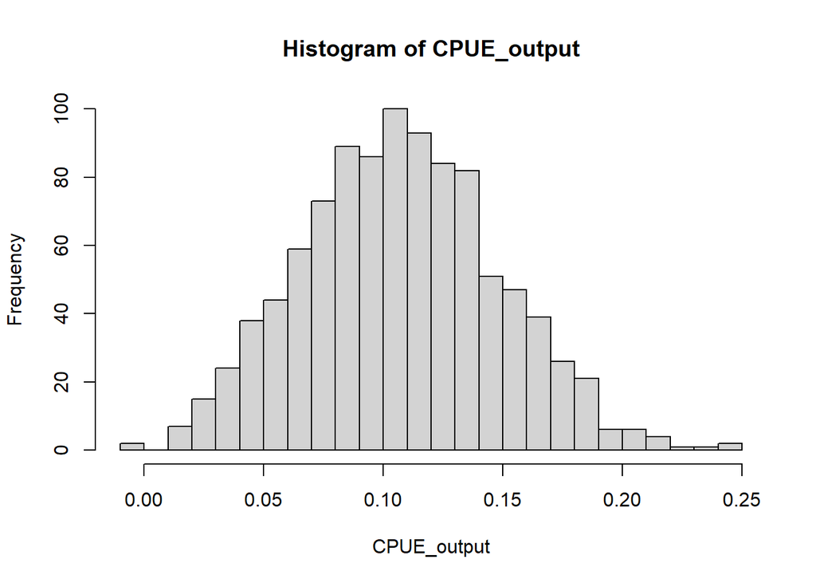

```r
cpue_raw_1990_small15<- cpue_boot(mat_1990, raw_data_only = TRUE)
```

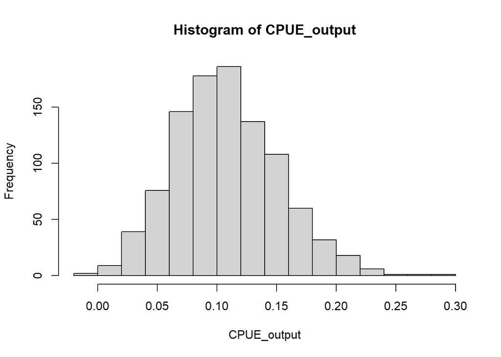

```r
cpue_1990_small15
```

```
## $mean
## [1] 0.1068541
##
## $sd
## [1] 0.04094947
```

### Let’s see what it looks like if we kept in ALL the depths under 90 ft

```r
data_1990%>%
  group_by(trans, trap_number)%>%
  count()%>%
  nrow()
```

```
## [1] 180
```

```r
matricized_1990<- data_1990%>%
  filter(depth <90)%>%
  group_by(trans, trap_number)%>%
  summarise(
    count = sum(tl >= 450)
  )%>%
  select(transect_number = trans, trap_number, count)%>%
  mutate(across(everything(), ~replace_na(.x,0)))


num_sets<- nrow(matricized_1990)
print("number of sets acrpss all depths in 1990")
```

```
## [1] "number of sets acrpss all depths in 1990"
```

```r
print(num_sets)
```

```
## [1] 147
```

```r
transect_numbers<- length(unique(matricized_1990$transect_number))
transect_sizes<-matricized_1990%>%
  group_by(transect_number)%>%
  summarise(
    transect_sizes= n_distinct(trap_number)
  )




max_transect_size<- max(transect_sizes$transect_sizes)


transect_matrix_1990<- matrix(NA, nrow = transect_numbers, ncol = max_transect_size)


mat_1990<- pop_mat(matricized_1990, transect_matrix_1990, transect_numbers)
```

```
## [1] "true"
```

```r
#now we have the matrix.

cpue_1990_alldata<- cpue_boot(mat_1990)
```

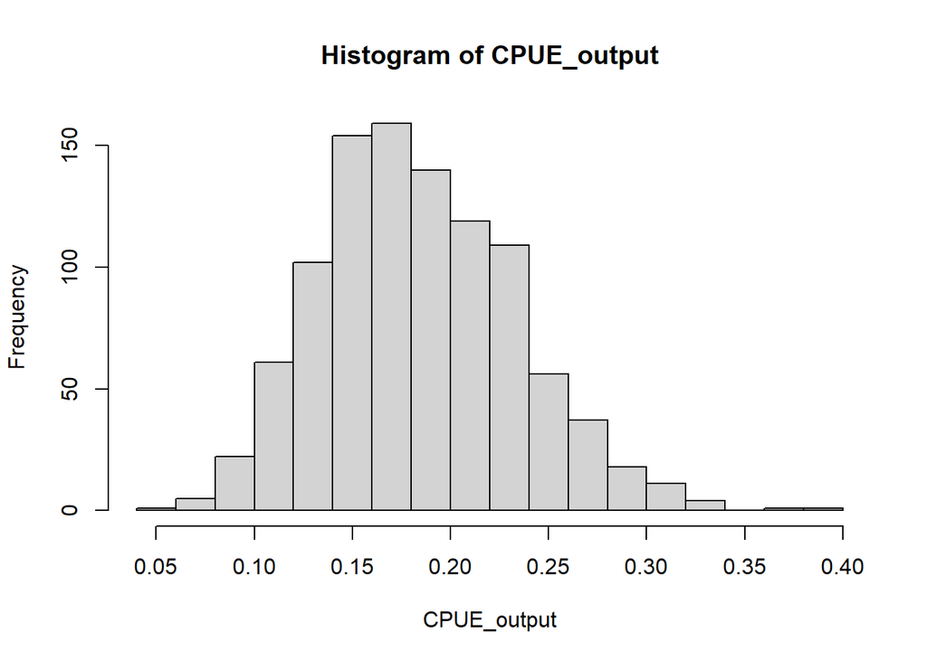

```r
cpue_raw_1990_alldata<- cpue_boot(mat_1990, raw_data_only = TRUE)
```

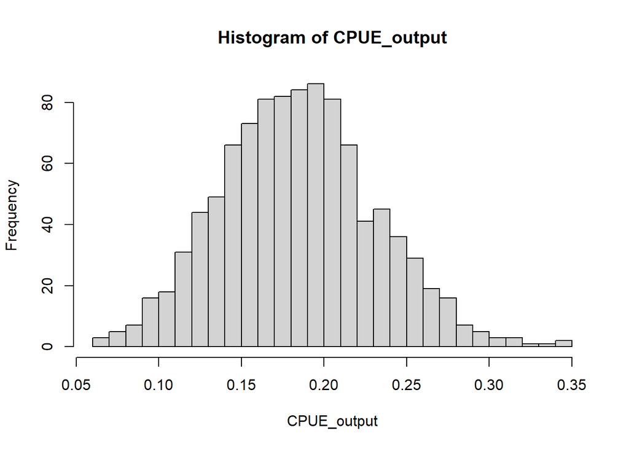

```r
cpue_1990_alldata
```

```
## $mean
## [1] 0.1838491
##
## $sd
## [1] 0.04967549
```

### this is normal and follows the Rao-Wu stipulation.

### Now let’s try it for only fish caught in > 15 m

```r
#now let's try for fish > 15 m only

data_1990%>%
  filter(depth >= 15*3.28084)%>%
  group_by(trans, trap_number)%>%
  count()%>%
  nrow()
```

```
## [1] 89
```

```r
matricized_1990<- data_1990%>%
  group_by(trans, trap_number)%>%
  filter(depth>15*3.28084)%>%
  summarise(
    count = sum(tl >=450)
  )%>%
  select(transect_number = trans, trap_number, count)%>%
  mutate(across(everything(), ~replace_na(.x,0)))


transect_numbers<- length(unique(matricized_1990$transect_number))
transect_sizes<-matricized_1990%>%
  group_by(transect_number)%>%
  summarise(
    transect_sizes= n_distinct(trap_number)
  )

num_sets<- nrow(matricized_1990)
print("number of sets in deep water > 15 m in 1990")
```

```
## [1] "number of sets in deep water > 15 m in 1990"
```

```r
print(num_sets)
```

```
## [1] 89
```

```r
max_transect_size<- max(transect_sizes$transect_sizes)


transect_matrix_1990<- matrix(NA, nrow = transect_numbers, ncol = max_transect_size)


mat_1990<- pop_mat(matricized_1990, transect_matrix_1990, transect_numbers)
```

```
## [1] "true"
```

```r
#now we have the matrix.

cpue_1990_large15<- cpue_boot(mat_1990)
```

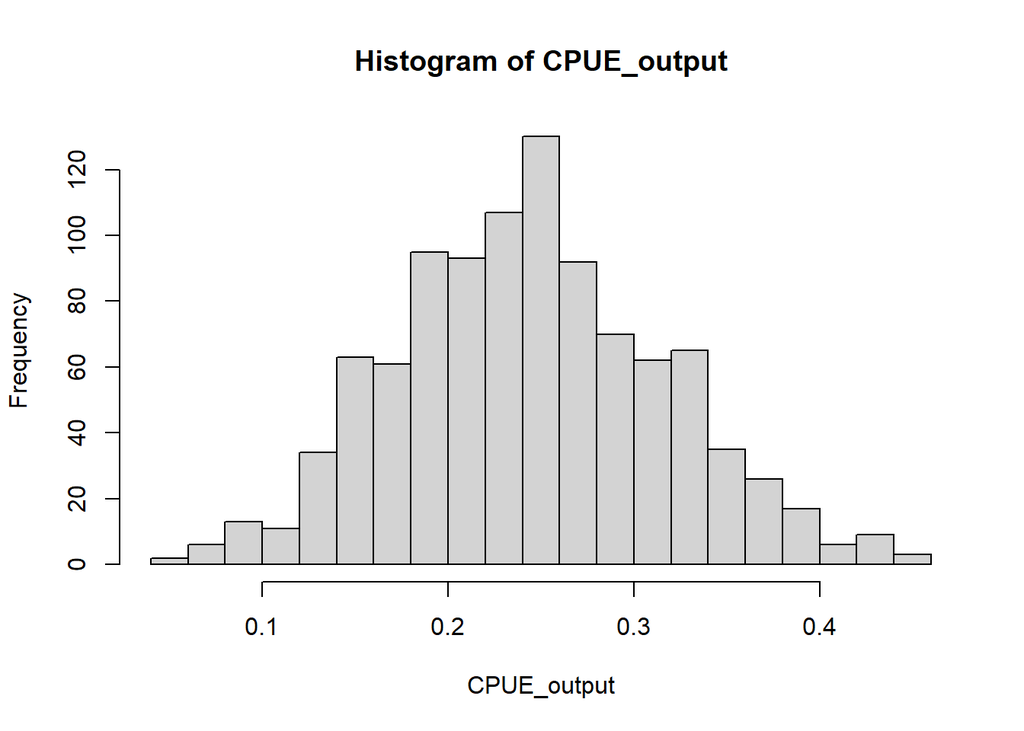

```r
cpue_raw_1990_large15<- cpue_boot(mat_1990, raw_data_only = TRUE)
```

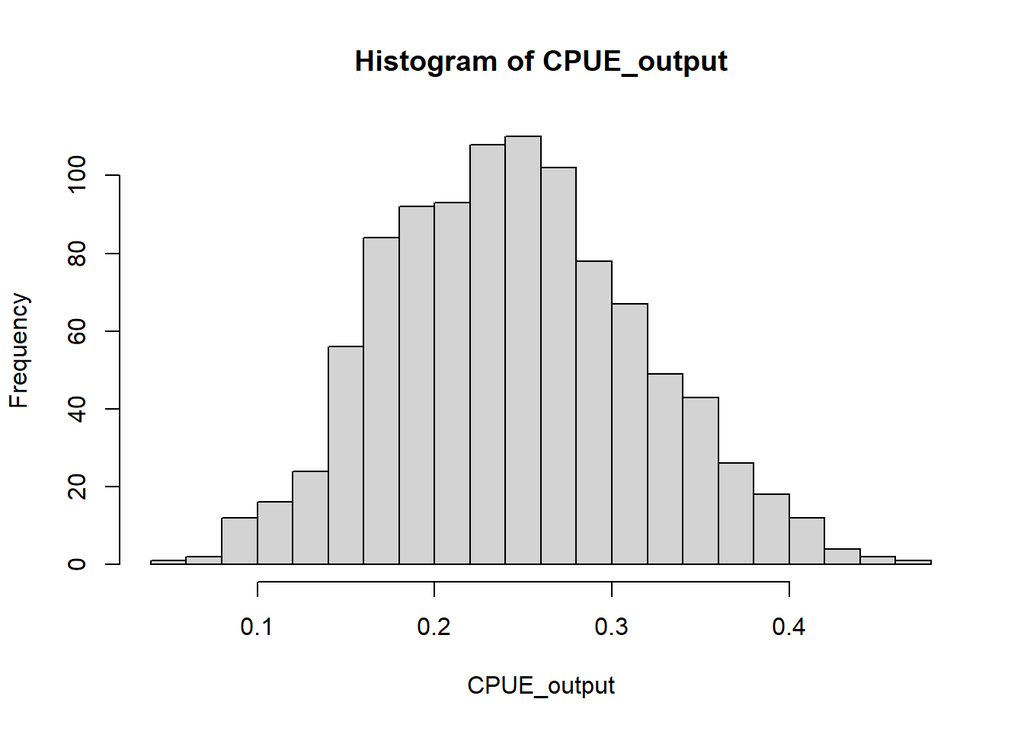

```r
cpue_1990_large15
```

```
## $mean
## [1] 0.2436202
##
## $sd
## [1] 0.07234959
```

### Let’s look at 1991

```r
#################Let's do the same thing for 1991

data_1991<-read_excel("1991_dat.xlsx")

colnames(data_1991)
```

```
##  [1] "con't"         "Trap #"        "Trans"         "Trap Loc"
##  [5] "Depth"         "...6"          "time set"      "time pulled"
##  [9] "...9"          "Species"       "# caught...11" "TL"
## [13] "Tag #"         "...14"         "...15"         "...16"
## [17] "...17"         "...18"         "...19"         "...20"
## [21] "...21"         "species"       "# caught...23" "...24"
## [25] "...25"         "...26"         "...27"         "...28"
## [29] "...29"         "...30"         "...31"         "...32"
## [33] "...33"         "...34"         "...35"         "...36"
## [37] "...37"         "...38"         "...39"         "...40"
## [41] "...41"         "...42"         "...43"         "...44"
## [45] "...45"         "...46"         "...47"         "...48"
## [49] "...49"
```

```r
data_1991<-janitor::remove_empty(data_1991)

data_1991<- clean_names(data_1991)

data_1991
```

```
## # A tibble: 312 × 32
##    cont  trap_number trans trap_loc depth time_set time_pulled species
##    <chr>       <dbl> <dbl>    <dbl> <dbl>    <dbl>       <dbl>   <dbl>
##  1 "\"N"          63     1        1    67       14          10     590
##  2 "\"N"          63     1        1    67       14          10     590
##  3 "\"N"          63     1        1    67       14          10     590
##  4 "\"N"         112     2        1    13       14          10     590
##  5 "\"N"         128     3        1    30       14          10     590
##  6 "\"N"          44     3        2    33       14          10     590
##  7 "\"N"          54     4        1    41       14          10     590
##  8 "\"N"          49     5        1    23       14          10     590
##  9 "\"N"          48     6        1    18       14           9     590
## 10 "\"N"         120     6        2    73       14           9     590
## # ℹ 302 more rows
## # ℹ 24 more variables: number_caught_11 <dbl>, tl <dbl>, tag_number <dbl>,
## #   x15 <chr>, x16 <chr>, x17 <dbl>, x18 <dbl>, x20 <chr>, x21 <dbl>,
## #   species_2 <dbl>, number_caught_23 <dbl>, x28 <dbl>, x29 <dbl>, x30 <dbl>,
## #   x31 <dbl>, x32 <chr>, x33 <dbl>, x36 <chr>, x38 <chr>, x39 <dbl>,
## #   x42 <dbl>, x43 <dbl>, x48 <dbl>, x49 <chr>
```

```r
data_1991%>%
  filter(depth <= 15*3.28084)%>%
  group_by(trans, trap_number)%>%
  count()%>%
  nrow()
```

```
## [1] 190
```

```r
# we need to apply the CPUE bootstrap to this.

matricized_1991<- data_1991%>%
  filter(depth<=15*3.28084)%>%
  group_by(trans, trap_number)%>%
  summarise(
    count = sum(tl >=450)
  )%>%
  select(transect_number = trans, trap_number, count)%>%
  mutate(across(everything(), ~replace_na(.x,0)))

num_sets<- nrow(matricized_1991)
print("number of sets in shallow water < 15 m in 1991")
```

```
## [1] "number of sets in shallow water < 15 m in 1991"
```

```r
print(num_sets)
```

```
## [1] 190
```

```r
transect_numbers<- lengtransect_numbers<- length(unique(matricized_1991$transect_number))
transect_sizes<-matricized_1991%>%
  group_by(transect_number)%>%
  summarise(
    transect_sizes= n_distinct(trap_number)
  )




max_transect_size<- max(transect_sizes$transect_sizes)


transect_matrix_1991<- matrix(NA, nrow = transect_numbers, ncol = max_transect_size)


mat_1991<- pop_mat(matricized_1991, transect_matrix_1991, transect_numbers)
```

```
## [1] "true"
```

```r
#now we have the matrix.

cpue_1991_small15<- cpue_boot(mat_1991)
```

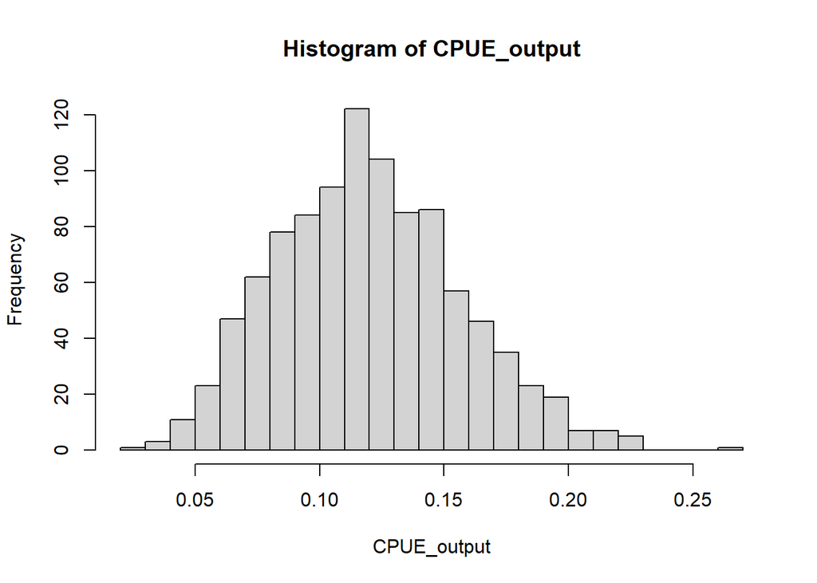

```r
cpue_raw_1991_small15<- cpue_boot(mat_1991, raw_data_only = TRUE)
```

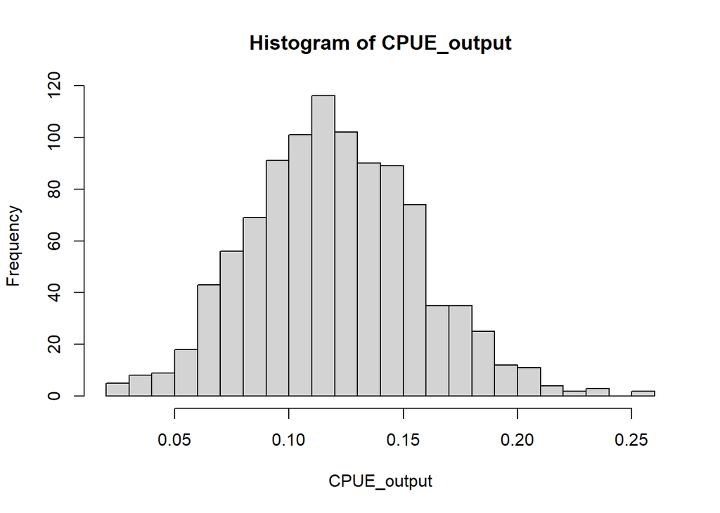

```r
cpue_1991_small15
```

```
## $mean
## [1] 0.1197954
##
## $sd
## [1] 0.03685124
```

### Let’s try it with all data not stratifying by depth

```r
data_1991%>%
  group_by(trans, trap_number)%>%
  count()%>%
  nrow()
```

```
## [1] 300
```

```r
matricized_1991<- data_1991%>%
  group_by(trans, trap_number)%>%
  summarise(
    count = sum(tl >= 450)
  )%>%
  select(transect_number = trans, trap_number, count)%>%
  mutate(across(everything(), ~replace_na(.x,0)))

num_sets<- nrow(matricized_1991)
print("number of sets across depths in 1991")
```

```
## [1] "number of sets across depths in 1991"
```

```r
print(num_sets)
```

```
## [1] 300
```

```r
transect_numbers<- length(unique(matricized_1991$transect_number))
transect_sizes<-matricized_1991%>%
  group_by(transect_number)%>%
  summarise(
    transect_sizes= n_distinct(trap_number)
  )




max_transect_size<- max(transect_sizes$transect_sizes)


transect_matrix_1991<- matrix(NA, nrow = transect_numbers, ncol = max_transect_size)


mat_1991<- pop_mat(matricized_1991, transect_matrix_1991, transect_numbers)
```

```
## [1] "true"
```

```r
#now we have the matrix.

cpue_1991_alldata<- cpue_boot(mat_1991)
```

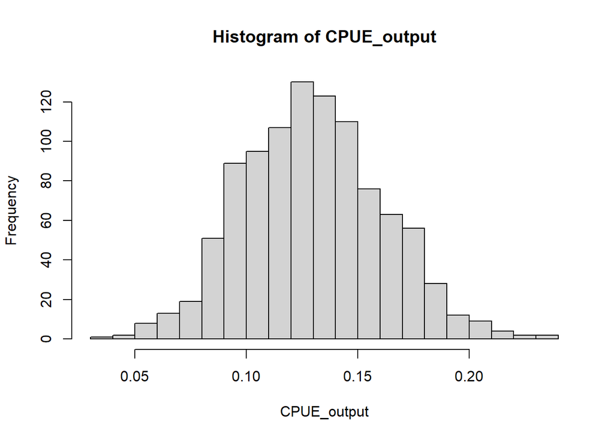

```r
cpue_raw_1991_alldata<- cpue_boot(mat_1991, raw_data_only = TRUE)
```

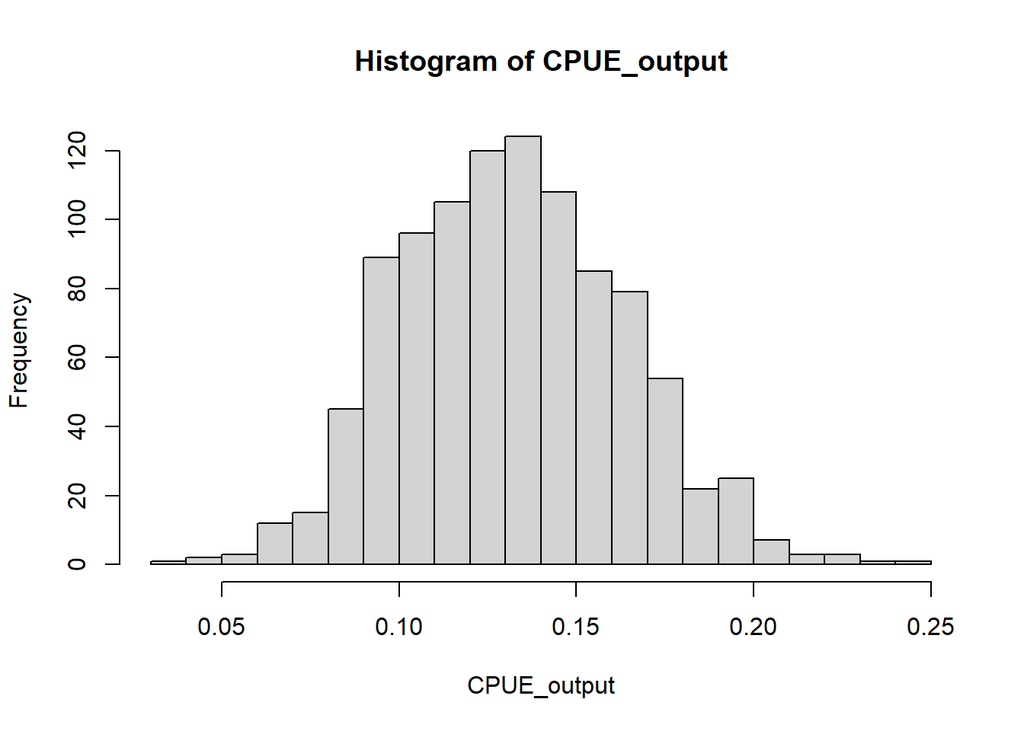

```r
cpue_1991_alldata
```

```
## $mean
## [1] 0.1297864
##
## $sd
## [1] 0.03167462
```

### this is normal and follows the Rao-Wu stipulation.

### now let’s try for fish > 15 m only

```r
data_1991%>%
  filter(depth >= 15*3.28084)%>%
  group_by(trans, trap_number)%>%
  count()%>%
  nrow()
```

```
## [1] 109
```

```r
matricized_1991<- data_1991%>%
  group_by(trans, trap_number)%>%
  filter(depth>=15*3.28084)%>%
  summarise(
    count = sum(tl >=450)
  )%>%
  select(transect_number = trans, trap_number, count)%>%
  mutate(across(everything(), ~replace_na(.x,0)))

num_sets<- nrow(matricized_1991)
print("number of sets in deep water > 15 m in 1991")
```

```
## [1] "number of sets in deep water > 15 m in 1991"
```

```r
print(num_sets)
```

```
## [1] 109
```

```r
transect_numbers<- length(unique(matricized_1991$transect_number))
transect_sizes<-matricized_1991%>%
  group_by(transect_number)%>%
  summarise(
    transect_sizes= n_distinct(trap_number)
  )




max_transect_size<- max(transect_sizes$transect_sizes)


transect_matrix_1991<- matrix(NA, nrow = transect_numbers, ncol = max_transect_size)


mat_1991<- pop_mat(matricized_1991, transect_matrix_1991, transect_numbers)
```

```
## [1] "true"
```

```r
#now we have the matrix.

cpue_1991_large15<- cpue_boot(mat_1991)
```

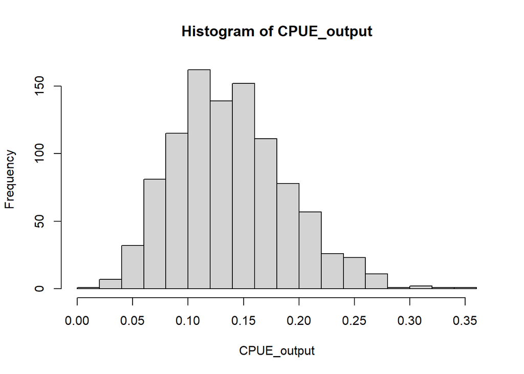

```r
cpue_raw_1991_large15<- cpue_boot(mat_1991, raw_data_only = TRUE)
```

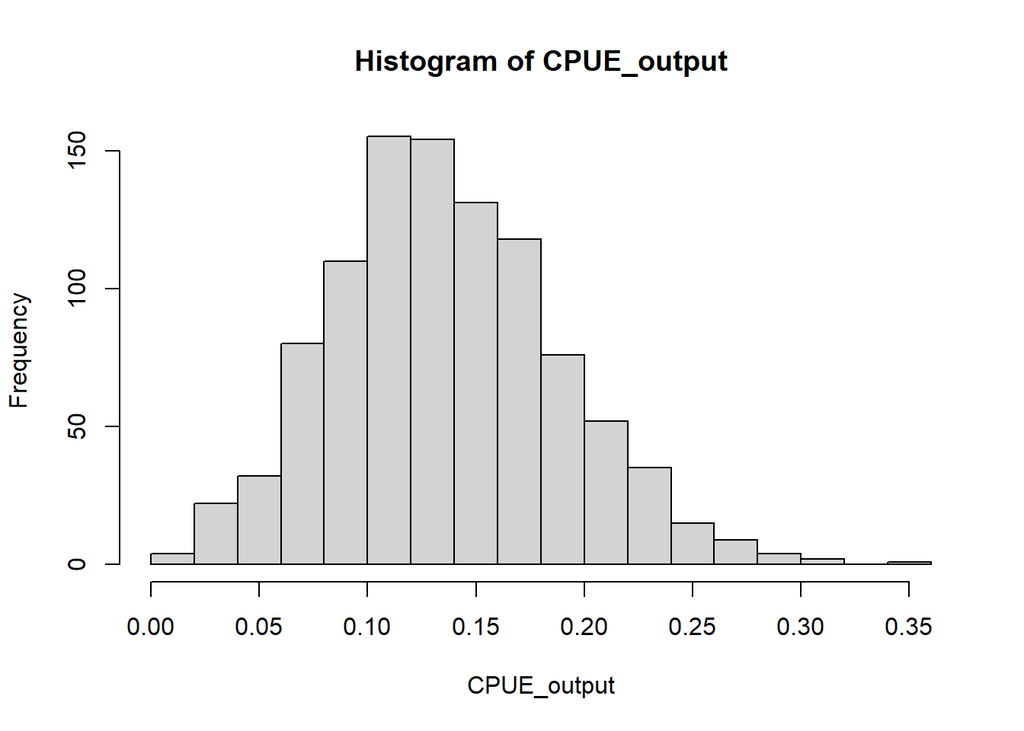

```r
cpue_1991_large15
```

```
## $mean
## [1] 0.1386206
##
## $sd
## [1] 0.05115779
```

Now let’s make a table

```r
cpue_1991_alldata
```

```
## $mean
## [1] 0.1297864
##
## $sd
## [1] 0.03167462
```

```r
cpue_1990_alldata
```

```
## $mean
## [1] 0.1838491
##
## $sd
## [1] 0.04967549
```

```r
df_all <- data.frame(
  "cpue mean" = c(cpue_1990_alldata$mean, cpue_1991_alldata$mean),
  "SE" = c(cpue_1990_alldata$sd, cpue_1991_alldata$sd),
  row.names = c("1990", "1991")
)


df_shallow <- data.frame(
  "cpue mean" = c(cpue_1990_small15$mean, cpue_1991_small15$mean),
  "SE" = c(cpue_1990_small15$sd, cpue_1991_small15$sd),
  row.names = c("1990", "1991")
)


df_deep <- data.frame(
  "cpue mean" = c(cpue_1990_large15$mean, cpue_1991_large15$mean),
  "SE" = c(cpue_1990_large15$sd, cpue_1991_large15$sd),
  row.names = c("1990", "1991")
)


kable(df_all)
```

|  | cpue.mean | SE |
| --- | --- | --- |
| 1990 | 0.1838491 | 0.0496755 |
| 1991 | 0.1297864 | 0.0316746 |

```r
kable(df_shallow)
```

|  | cpue.mean | SE |
| --- | --- | --- |
| 1990 | 0.1068541 | 0.0409495 |
| 1991 | 0.1197954 | 0.0368512 |

```r
kable(df_deep)
```

|  | cpue.mean | SE |
| --- | --- | --- |
| 1990 | 0.2436202 | 0.0723496 |
| 1991 | 0.1386206 | 0.0511578 |

```r
#get the raw data


#cpue_output_df<- data.frame(
#  shallow_1990 = cpue_raw_1990_small15,
#  deep_1990 = cpue_raw_1990_large15,
#  all_1990 = cpue_raw_1990_alldata,
#  shallow_1991 = cpue_raw_1991_small15,
#  deep_1991 = cpue_raw_1991_large15,
#  all_1991 = cpue_raw_1991_alldata,
#)


#head(cpue_output_df)
```

Questions:

1. Is it fair to assume that the distribution of fish is the same in shallow and deeper parts of the lake? Is it fair to assume that shallow CPUE is a proxy for fish availability